# Logistic regression lab

```r
library(dplyr)  # optional
library(gdata)  # optional
library(bestglm)
```

# Credit scoring: a case study

When issuing credit, banks check the “solvency” or “creditworthiness” of the client, i.e. the ability to pay back the credit.

“Solvency” can be evaluated by a statistical model that tries to predict the probability that a credit is payed back from knowing some economic or personal characteristics of the borrower.

Binary regression models are suited for this situation.

## Data

We will consider the dataset `credit`from `Fahrmeir` library [^1]. This are data for $1000$ clients of a south german bank, $700$ good payers and $300$ bad payers. They are used to construct a credit scoring method.

Every client is associated with a factor $Y$ with levels:
$$\begin{align*}
& buen & \text{the client payed back his loan}\\
& mal & \text{the client did not pay back his loan}
\end{align*}$$

Other characteristics were observed and could be used as covariates:

- `Cuenta`: no, bad running, good running (quality of the credit client bank account)
- `Mes`: duration of loan in months
- `Ppag`: pre buen pagador, pre mal pagador (previous payment behaviour)
- `Uso`: privado, profesional (the use to which the loan is made)
- `DM`: credit amount in german marks
- `Sexo`: mujer, hombre (sex of the client)
- `Estc`: no vive solo, vive solo (civil state of the client)
1. Let’s load the data, look at the first records and the structure and have a summary:

```
     Y      Cuenta Mes             Ppag         Uso   DM   Sexo         Estc
1 buen          no  18 pre buen pagador     privado 1049  mujer    vive solo
2 buen          no   9 pre buen pagador profesional 2799 hombre no vive solo
3 buen bad running  12 pre buen pagador profesional  841  mujer    vive solo
4 buen          no  12 pre buen pagador profesional 2122 hombre no vive solo
5 buen          no  12 pre buen pagador profesional 2171 hombre no vive solo
6 buen          no  10 pre buen pagador profesional 2241 hombre no vive solo
'data.frame':   1000 obs. of  8 variables:
 $ Y     : Factor w/ 2 levels "buen","mal": 1 1 1 1 1 1 1 1 1 1 ...
 $ Cuenta: Factor w/ 3 levels "no","good running",..: 1 1 3 1 1 1 1 1 2 3 ...
 $ Mes   : num  18 9 12 12 12 10 8 6 18 24 ...
 $ Ppag  : Factor w/ 2 levels "pre buen pagador",..: 1 1 1 1 1 1 1 1 1 1 ...
 $ Uso   : Factor w/ 2 levels "privado","profesional": 1 2 2 2 2 2 2 2 1 1 ...
 $ DM    : num  1049 2799 841 2122 2171 ...
 $ Sexo  : Factor w/ 2 levels "mujer","hombre": 1 2 1 2 2 2 2 2 1 1 ...
 $ Estc  : Factor w/ 2 levels "no vive solo",..: 2 1 2 1 1 1 1 1 2 2 ...
    Y                Cuenta         Mes                     Ppag
 buen:700   no          :274   Min.   : 4.0   pre buen pagador:911
 mal :300   good running:394   1st Qu.:12.0   pre mal pagador : 89
            bad running :332   Median :18.0
                               Mean   :20.9
                               3rd Qu.:24.0
                               Max.   :72.0
          Uso            DM            Sexo               Estc
 privado    :657   Min.   :  250   mujer :402   no vive solo:640
 profesional:343   1st Qu.: 1366   hombre:598   vive solo   :360
                   Median : 2320
                   Mean   : 3271
                   3rd Qu.: 3972
                   Max.   :18424
```

2. Let’s clean the data, in particular make factor level names shorter and with meaningful order.

```r
credit %>% attach()
Y %>% levels()
[1] "buen" "mal"
Y %>% table
.
buen  mal
 700  300
Y %>% unclass %>% table
.
  1   2
700 300
credit %>% detach()
```

```r
credit_c <- credit
names(credit_c) <- names(credit_c) %>% tolower()
credit_c %>% names
[1] "y"      "cuenta" "mes"    "ppag"   "uso"    "dm"     "sexo"   "estc"

credit_c %>% select_if(is.factor) %>% sapply(levels)
$y
[1] "buen" "mal"

$cuenta
[1] "no"           "good running" "bad running"

$ppag
[1] "pre buen pagador" "pre mal pagador"

$uso
[1] "privado"     "profesional"

$sexo
[1] "mujer"  "hombre"

$estc
[1] "no vive solo" "vive solo"
credit_c %>% summarise_all(funs(list(levels(.))))
          y                        cuenta  mes                              ppag
1 buen, mal no, good running, bad running NULL pre buen pagador, pre mal pagador
                   uso   dm          sexo                    estc
1 privado, profesional NULL mujer, hombre no vive solo, vive solo

credit_c %>% select_if(is.factor) %>% sapply(mapLevels)
$y
buen  mal
   1    2

$cuenta
          no good running  bad running
           1            2            3

$ppag
pre buen pagador  pre mal pagador
               1                2

$uso
    privado profesional
          1           2

$sexo
 mujer hombre
     1      2

$estc
no vive solo    vive solo
           1            2
```

In particular, replace levels of `y` by 0/1, rename levels of the remaining by making them (at least) shorter and possibly by translating to English (levels order can be maintained).

```
credit_c$y <- ???
# check:
???

??? credit_c$cuenta ???
??? credit_c$ppag ???
...
...
```

To make variables directly available in the sequel:

```r
credit_c %>% attach
```

## Exploration

First we may want to get an idea of the main variables.

How many clients did not repaid the loan?

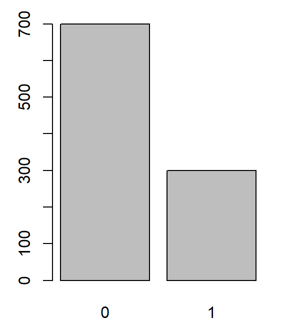

```r
y %>% table
.
  0   1
700 300
y %>% table %>% barplot
```

```r
credit_c %>% detach
```

30% did not repaid the loan.

3. Carry out an exploratory analysis of the covariates, both marginally and jointly.

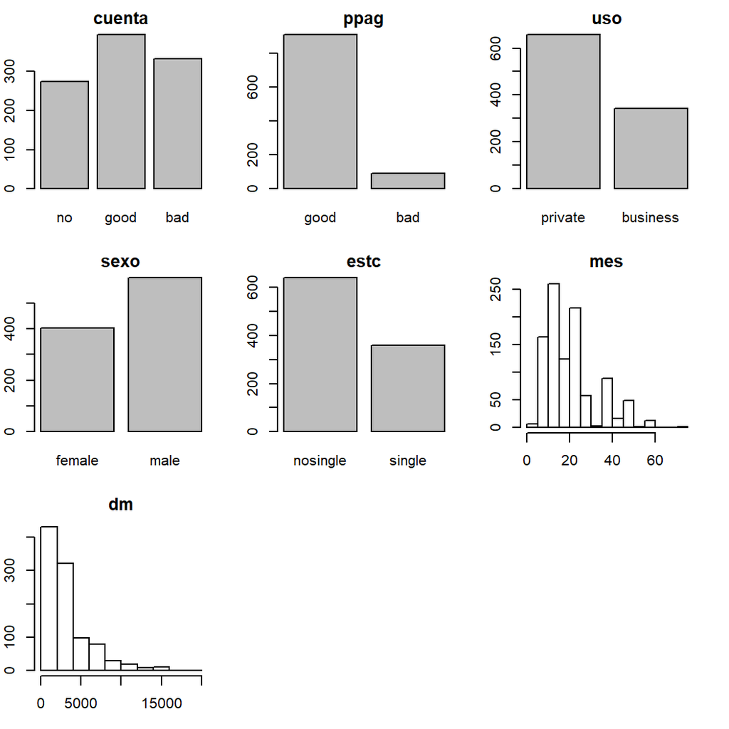

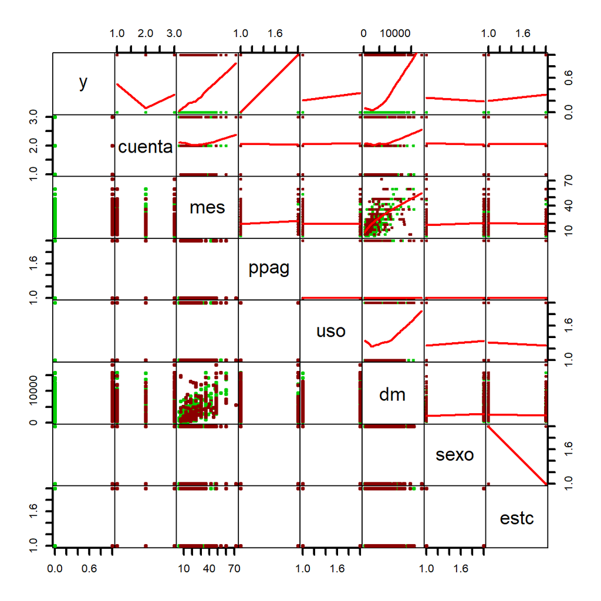

```
   cuenta
y          no      good       bad
  0 0.1985714 0.4971429 0.3042857
  1 0.4500000 0.1533333 0.3966667
   ppag
y         good        bad
  0 0.94857143 0.05142857
  1 0.82333333 0.17666667
   uso
y     private  business
  0 0.6928571 0.3071429
  1 0.5733333 0.4266667
   sexo
y      female      male
  0 0.3828571 0.6171429
  1 0.4466667 0.5533333
   estc
y   nosingle single
  0     0.67   0.33
  1     0.57   0.43
```

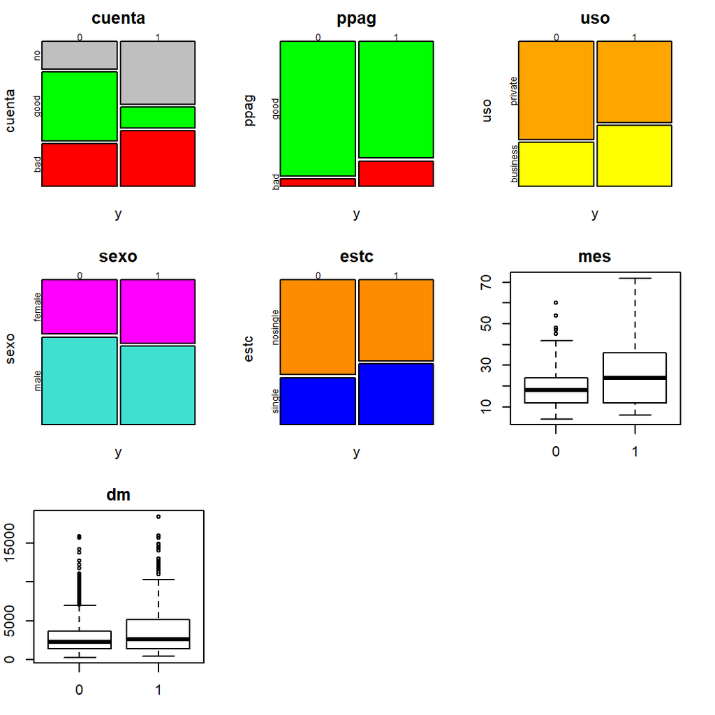

## A logistic regression model

We can now try to estimate a logistic regression model with all covariates included.

```r
mod_c <- glm(y ~ ., family = binomial(link = logit), data = credit_c)
summary(mod_c)

Call:
glm(formula = y ~ ., family = binomial(link = logit), data = credit_c)

Deviance Residuals:
    Min       1Q   Median       3Q      Max
-2.0572  -0.8050  -0.4581   0.9483   2.4655

Coefficients:
              Estimate Std. Error z value Pr(>|z|)
(Intercept) -1.178e+00  2.693e-01  -4.374 1.22e-05 ***
cuentagood  -1.952e+00  2.060e-01  -9.472  < 2e-16 ***
cuentabad   -6.346e-01  1.764e-01  -3.598 0.000321 ***
mes          3.503e-02  7.849e-03   4.463 8.10e-06 ***
ppagbad      9.884e-01  2.529e-01   3.907 9.33e-05 ***
usobusiness  4.744e-01  1.605e-01   2.956 0.003112 **
dm           3.242e-05  3.335e-05   0.972 0.330893
sexomale    -2.235e-01  2.208e-01  -1.012 0.311453
estcsingle   3.854e-01  2.194e-01   1.757 0.078921 .
---
Signif. codes:  0 '***' 0.001 '**' 0.01 '*' 0.05 '.' 0.1 ' ' 1

(Dispersion parameter for binomial family taken to be 1)

    Null deviance: 1221.7  on 999  degrees of freedom
Residual deviance: 1017.3  on 991  degrees of freedom
AIC: 1035.3

Number of Fisher Scoring iterations: 4
```

4. Comment on the results (significance, interpretation).

```r
exp(mod_c$coefficients[c(2:3, 5, 6)])
 cuentagood   cuentabad     ppagbad usobusiness
  0.1420360   0.5301221   2.6868533   1.6070469
```

5. What is the interpretation of the above result?

### A more complicated model

The model can be complicated by trying to see if there is a non linear effect of the two quantitative covariates.

6. Consider a parabolic effect in the new model (try also `update` routine).

```
Call:
glm(formula = y ~ cuenta + mes + ppag + uso + dm + sexo + estc +
    I(mes^2) + I(dm^2), family = binomial(link = logit), data = credit_c)

Deviance Residuals:
    Min       1Q   Median       3Q      Max
-2.5094  -0.7844  -0.4684   0.9195   2.5150

Coefficients:
              Estimate Std. Error z value Pr(>|z|)
(Intercept) -1.385e+00  3.665e-01  -3.780 0.000157 ***
cuentagood  -1.950e+00  2.070e-01  -9.419  < 2e-16 ***
cuentabad   -6.324e-01  1.777e-01  -3.558 0.000373 ***
mes          9.126e-02  2.545e-02   3.586 0.000335 ***
ppagbad      9.964e-01  2.565e-01   3.885 0.000102 ***
usobusiness  4.481e-01  1.623e-01   2.762 0.005751 **
dm          -2.449e-04  1.000e-04  -2.448 0.014361 *
sexomale    -1.764e-01  2.218e-01  -0.795 0.426536
estcsingle   3.991e-01  2.205e-01   1.810 0.070252 .
I(mes^2)    -8.666e-04  4.149e-04  -2.089 0.036745 *
I(dm^2)      2.203e-08  7.528e-09   2.927 0.003424 **
---
Signif. codes:  0 '***' 0.001 '**' 0.01 '*' 0.05 '.' 0.1 ' ' 1

(Dispersion parameter for binomial family taken to be 1)

    Null deviance: 1221.7  on 999  degrees of freedom
Residual deviance: 1006.2  on 989  degrees of freedom
AIC: 1028.2

Number of Fisher Scoring iterations: 4
```

It seems we have improved our model.

7. Test if adding a parabolic effect of the two quantitative covariates has significantly improved the model (hint: compare the deviances of the two models or other measures of comparison).

E.g.

```
1035.347 versus 1028.218
```

### Prediction

A possible use of the model is to predict insolvency for a new client who wants to borrow a given amount from the bank. The model could be used to decide to deny the loan if this probability is judged to be too high. In this case we assume that information on the covariates are available at the moment the bank has to decide.

8. Consider a client with the following characteristics: It has no running account, the term for repaying the debt is 36 months, the amount is 10000 dm, previous payment behaviour was bad and the money are intended to be used for business. How risky is to give a loan to him? The predicted probability of insolvency is:

```
newclient <- data.frame(cuenta="no", ... , ... , .... , ..., ..., ...)
predict(..., newdata=newclient, type="response")
```

```
        1
0.9001205
```

Our prediction shows that it could be very risky!

### Best subset selection

We can perform an exhaustive search for the best subset of regressors by using a new function, `bestglm`, equivalent to `leaps`(that we considered for linear models).

As always, read carefully the help for the new function. A summary is given below.

Function `bestglm` (of the omonymous library) carries out a best subset selection for glm models.

```
bestglm(Xy, family = gaussian, IC = "BIC", t = "default",
        CVArgs = "default", TopModels = 5, nvmax = "default", ...)
```

Information criteria to use: “AIC”, “BIC”, “BICg”, “BICq”, “LOOCV”, “CV”. CVArgs is used when IC is set to ‘CV’. The default is use the delete-d algorithm. CVArgs is a list with 3 named components: Method, K, REP, where Method is one of “HTF”, “DH”, “d” corresponding to using the functions CVHTM (Hastie et al., 2009, K-fold CV), CVDH (adjusted K-fold CV, Davison and Hartigan, 1997) and CVd (delete-d CV with random subsamples, Shao, 1997).

9. Find the best subset from the set of original variables.

```
Xy <- ...

bestlogistic <- bestglm(Xy = Xy, family = ..., IC = "...")
bestlogistic$BestModels
```

Otain a summary of the top-1 model

```
Morgan-Tatar search since family is non-gaussian.
Note: factors present with more than 2 levels.
  cuenta  mes ppag  uso    dm  sexo  estc Criterion
1   TRUE TRUE TRUE TRUE FALSE FALSE  TRUE  1031.099
2   TRUE TRUE TRUE TRUE FALSE  TRUE  TRUE  1032.289
3   TRUE TRUE TRUE TRUE  TRUE FALSE  TRUE  1032.366
4   TRUE TRUE TRUE TRUE  TRUE  TRUE  TRUE  1033.347
5   TRUE TRUE TRUE TRUE FALSE  TRUE FALSE  1033.602

Call:
glm(formula = y ~ ., family = family, data = Xi, weights = weights)

Deviance Residuals:
    Min       1Q   Median       3Q      Max
-2.0158  -0.8036  -0.4555   0.9417   2.4438

Coefficients:
             Estimate Std. Error z value Pr(>|z|)
(Intercept) -1.346193   0.210336  -6.400 1.55e-10 ***
cuentagood  -1.937717   0.205460  -9.431  < 2e-16 ***
cuentabad   -0.617390   0.175739  -3.513 0.000443 ***
mes          0.038855   0.006294   6.174 6.67e-10 ***
ppagbad      0.987716   0.252670   3.909 9.26e-05 ***
usobusiness  0.469401   0.159682   2.940 0.003286 **
estcsingle   0.532731   0.159122   3.348 0.000814 ***
---
Signif. codes:  0 '***' 0.001 '**' 0.01 '*' 0.05 '.' 0.1 ' ' 1

(Dispersion parameter for binomial family taken to be 1)

    Null deviance: 1221.7  on 999  degrees of freedom
Residual deviance: 1019.1  on 993  degrees of freedom
AIC: 1033.1

Number of Fisher Scoring iterations: 4
```

10. Now, include also the parabolic transformations of duratio and amount and repeat the exhaustive search.

```
Xy <- ... mes2=credit_c$mes^2, ...
      ... ...

bestlogistic2 <- bestglm(Xy = Xy, family = ..., IC = "...")
bestlogistic2$BestModels
```

```
Morgan-Tatar search since family is non-gaussian.
Note: factors present with more than 2 levels.
  cuenta  mes ppag  uso   dm  sexo  estc  mes2  dm2 Criterion
1   TRUE TRUE TRUE TRUE TRUE FALSE  TRUE  TRUE TRUE  1024.848
2   TRUE TRUE TRUE TRUE TRUE  TRUE  TRUE  TRUE TRUE  1026.218
3   TRUE TRUE TRUE TRUE TRUE FALSE  TRUE FALSE TRUE  1027.233
4   TRUE TRUE TRUE TRUE TRUE  TRUE FALSE  TRUE TRUE  1027.512
5   TRUE TRUE TRUE TRUE TRUE  TRUE  TRUE FALSE TRUE  1028.653

Call:
glm(formula = y ~ ., family = family, data = Xi, weights = weights)

Deviance Residuals:
    Min       1Q   Median       3Q      Max
-2.5623  -0.7934  -0.4686   0.9173   2.5127

Coefficients:
              Estimate Std. Error z value Pr(>|z|)
(Intercept) -1.508e+00  3.333e-01  -4.524 6.06e-06 ***
cuentagood  -1.946e+00  2.069e-01  -9.406  < 2e-16 ***
cuentabad   -6.260e-01  1.774e-01  -3.528 0.000418 ***
mes          9.100e-02  2.547e-02   3.573 0.000353 ***
ppagbad      9.911e-01  2.565e-01   3.865 0.000111 ***
usobusiness  4.385e-01  1.617e-01   2.712 0.006692 **
dm          -2.546e-04  9.938e-05  -2.562 0.010409 *
estcsingle   5.199e-01  1.603e-01   3.243 0.001184 **
mes2        -8.617e-04  4.157e-04  -2.073 0.038180 *
dm2          2.256e-08  7.516e-09   3.001 0.002687 **
---
Signif. codes:  0 '***' 0.001 '**' 0.01 '*' 0.05 '.' 0.1 ' ' 1

(Dispersion parameter for binomial family taken to be 1)

    Null deviance: 1221.7  on 999  degrees of freedom
Residual deviance: 1006.8  on 990  degrees of freedom
AIC: 1026.8

Number of Fisher Scoring iterations: 4
```

Do you get a better model?

[^1]: Example drawn from Fahrmeier and Tutz, Multivariate Generalized Linear Models, Springer Verlag.

Matilde Trevisani

2018-11-19